# essai_avec_K=5

Clémence CHESNAIS

2023-04-12

# Environnement de travail

```r
library(tidyverse)
library(stargazer)
library(gridExtra)
```

```r
library(corrplot)
library(cluster)
library(NbClust)
library(ade4)
library(FactoMineR)
```

Nous initialisons une graine aléatoire afin d’obtenir les mêmes résultats à chaque exécution.

```r
set.seed(1234)
```

# Question 1

## Importation des données

```r
donnees <- read.csv("Pays_donnees.csv",sep=",",dec=".",stringsAsFactors = T,row.names="pays")
str(donnees)
```

```
## 'data.frame':    167 obs. of  9 variables:
##  $ enfant_mort: num  90.2 16.6 27.3 119 10.3 14.5 18.1 4.8 4.3 39.2 ...
##  $ exports    : num  10 28 38.4 62.3 45.5 18.9 20.8 19.8 51.3 54.3 ...
##  $ sante      : num  7.58 6.55 4.17 2.85 6.03 8.1 4.4 8.73 11 5.88 ...
##  $ imports    : num  44.9 48.6 31.4 42.9 58.9 16 45.3 20.9 47.8 20.7 ...
##  $ revenu     : int  1610 9930 12900 5900 19100 18700 6700 41400 43200 16000 ...
##  $ inflation  : num  9.44 4.49 16.1 22.4 1.44 20.9 7.77 1.16 0.873 13.8 ...
##  $ esper_vie  : num  56.2 76.3 76.5 60.1 76.8 75.8 73.3 82 80.5 69.1 ...
##  $ fert       : num  5.82 1.65 2.89 6.16 2.13 2.37 1.69 1.93 1.44 1.92 ...
##  $ pib_h      : int  553 4090 4460 3530 12200 10300 3220 51900 46900 5840 ...
```

```r
# summary(donnees)
```

## Prétraitement des données

### Données manquantes

```r
sum(is.na(donnees))
```

```
## [1] 0
```

Le jeu de données ne présentent pas de valeur manquante. Nous n’avons pas besoin de faire de modification de ce point de vue.

### Standardisation des données

Nous pouvons remarquer que les données sont dans des unités différentes et les ordres de grandeur sont très variables. Ces boxplots nous montrent une différence notable entre les variables et nous incite à standardiser les données.

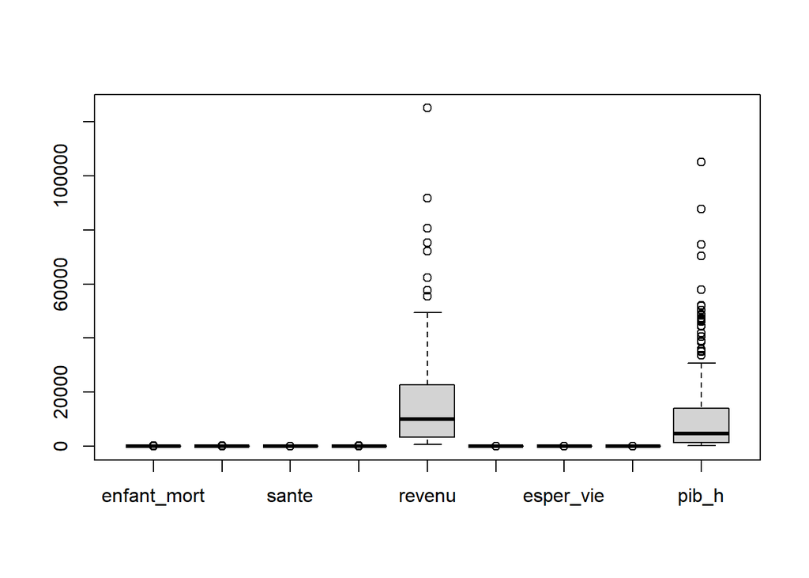

```r
boxplot(donnees)
```

Nous passons donc à la standardisation :

```r
donnees.sc <- scale(donnees)
```

Afin de pouvoir analyser ces données, nous allons réaliser des statistiques descriptives de base.

### Statistiques descriptives

On effectue les statistiques descriptives sur les valeurs avant standardisation.

Résumé des données :

```r
# stargazer(donnees,type="text",title="Résumé des données",out="resume_donnnees.txt")
```

Graphiques :

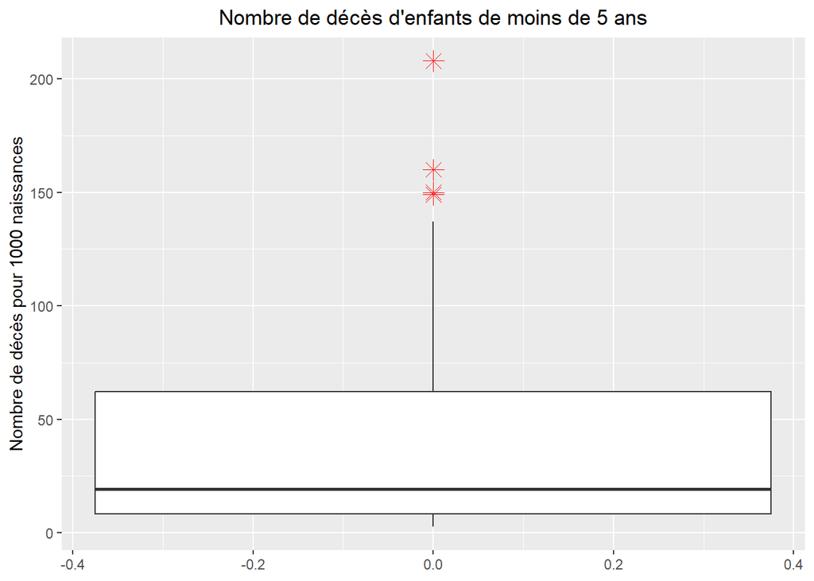

```r
ggplot(data=donnees, aes(y=enfant_mort)) +
  geom_boxplot(outlier.colour="red", outlier.shape=8,outlier.size=4)+
  labs(title="Nombre de décès d'enfants de moins de 5 ans",y="Nombre de décès pour 1000 naissances")+
  theme(plot.title = element_text(hjust=0.5))
```

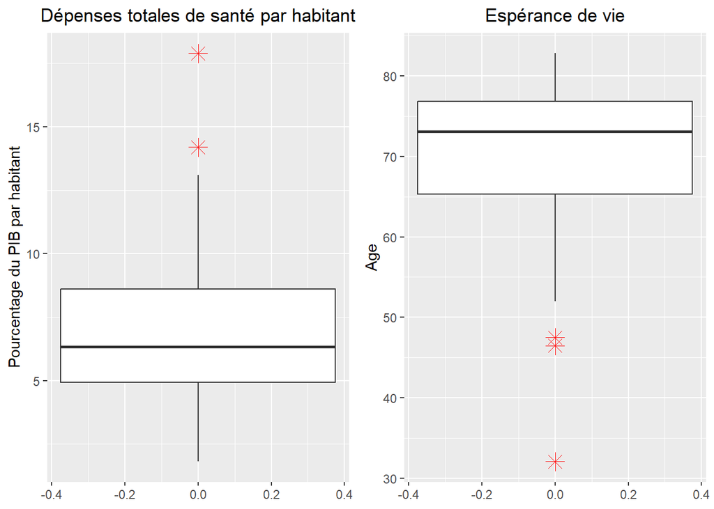

```r
sante <- ggplot(data=donnees, aes(y=sante)) +
  geom_boxplot(outlier.colour="red", outlier.shape=8,outlier.size=4)+
  labs(title="Dépenses totales de santé par habitant",y="Pourcentage du PIB par habitant")+
  theme(plot.title = element_text(hjust=0.5))

esperance <- ggplot(data=donnees, aes(y=esper_vie)) +
  geom_boxplot(outlier.colour="red", outlier.shape=8,outlier.size=4)+
  labs(title="Espérance de vie",y="Age")+
  theme(plot.title = element_text(hjust=0.5))

grid.arrange(sante,esperance,ncol=2)
```

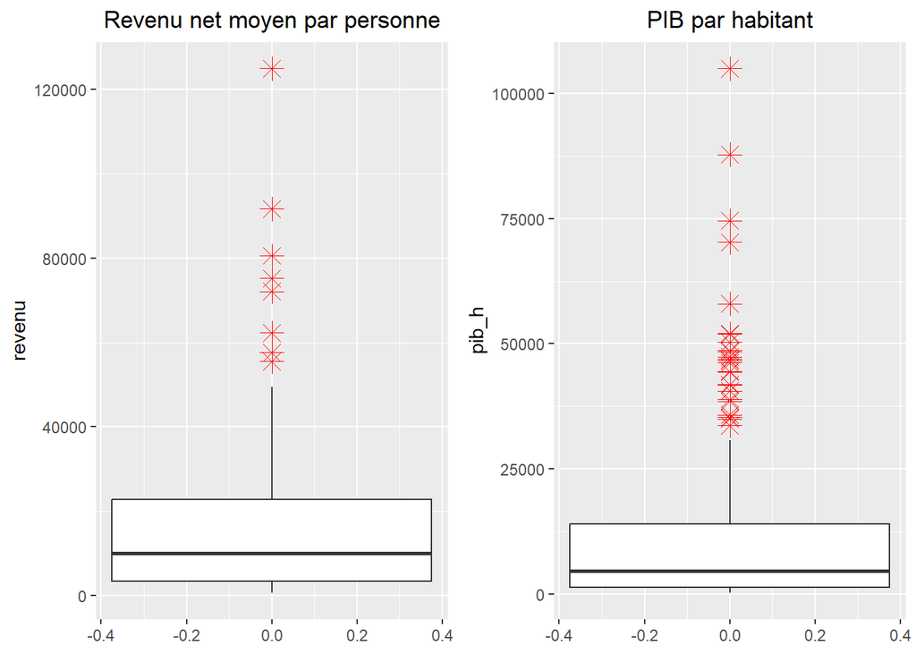

```r
revenu_net <- ggplot(data=donnees, aes(y=revenu)) +
  geom_boxplot(outlier.colour="red", outlier.shape=8,outlier.size=4)+
  labs(title="Revenu net moyen par personne")+
  theme(plot.title = element_text(hjust=0.5))

pib_hab <- ggplot(data=donnees, aes(y=pib_h)) +
  geom_boxplot(outlier.colour="red", outlier.shape=8,outlier.size=4)+
  labs(title="PIB par habitant")+
  theme(plot.title = element_text(hjust=0.5))

grid.arrange(revenu_net,pib_hab,ncol=2)
```

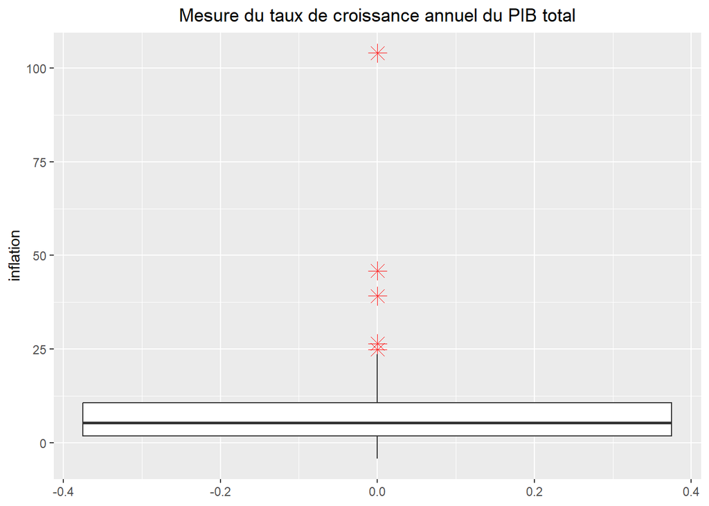

```r
ggplot(data=donnees, aes(y=inflation)) +
  geom_boxplot(outlier.colour="red", outlier.shape=8,outlier.size=4)+
  labs(title="Mesure du taux de croissance annuel du PIB total")+
  theme(plot.title = element_text(hjust=0.5))
```

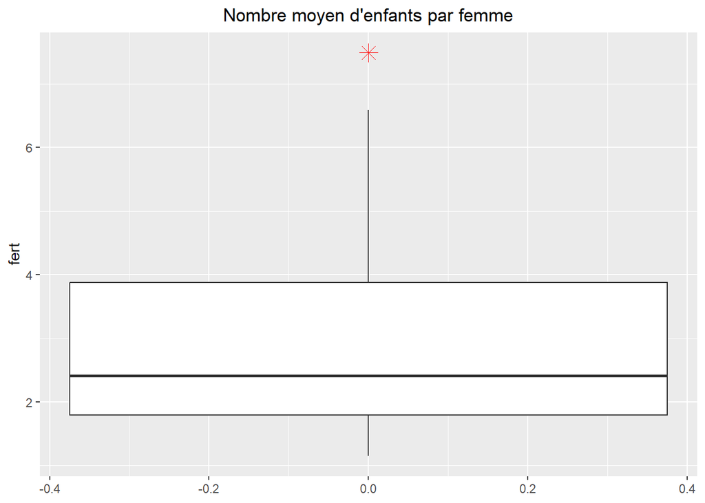

```r
ggplot(data=donnees, aes(y=fert)) +
  geom_boxplot(outlier.colour="red", outlier.shape=8,outlier.size=4)+
  labs(title="Nombre moyen d'enfants par femme")+
  theme(plot.title = element_text(hjust=0.5))
```

Imports et Exports :

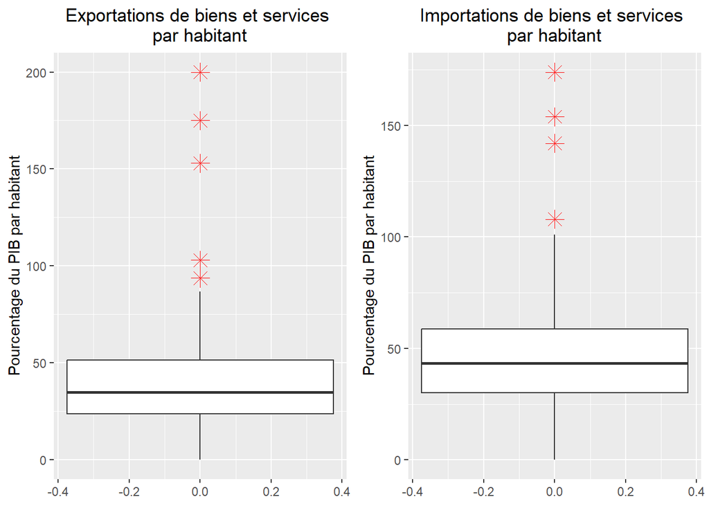

```r
imports <- ggplot(data=donnees, aes(y=imports)) +
  geom_boxplot(outlier.colour="red", outlier.shape=8,outlier.size=4)+
  labs(title="Importations de biens et services \npar habitant",y="Pourcentage du PIB par habitant")+
  theme(plot.title = element_text(hjust=0.5))

exports <- ggplot(data=donnees, aes(y=exports)) +
  geom_boxplot(outlier.colour="red", outlier.shape=8,outlier.size=4)+
  labs(title="Exportations de biens et services \npar habitant",y="Pourcentage du PIB par habitant")+
  theme(plot.title = element_text(hjust=0.5))

grid.arrange(exports, imports, ncol=2)
```

Matrice de corrélation :

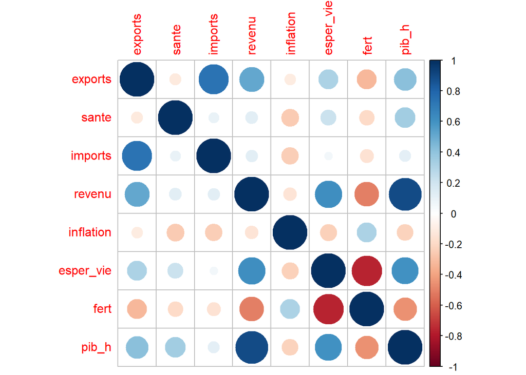

```r
corrplot(cor(donnees[-1]),method="circle")
```

Grâce à cette matrice de corrélation, nous pouvons observer une corrélation négative, entre l’espérance de vie et le nombre d’enfants par femme. Par ailleurs, une corrélation positive,proche de 1, apparaît entre le PIB par habitant et le revenu net moyen par personne.

# Question 2

Matrice de dissimilarité :

Afin de chercher les individus similaires, on peut calculer une matrice de distance / dissimilarité.

```r
MD <- as.matrix(dist(donnees.sc,method = "euclidean"))
# MD <- as.matrix(dist(donnees.sc,method = "minkowski"))
# MD <- as.matrix(dist(donnees.sc,method = "manhattan"))
which(MD == min(MD[row(MD)!=col(MD)]),arr.ind=TRUE)
```

```
##         row col
## Poland  122  42
## Croatia  42 122
```

Avec la méthode de la distance euclidienne, de manhattan et minkowski, les deux pays les plus proches / similaires sont la Pologne et la Croatie.

Dans notre situation, les variables sont quantitatives, nous pouvons donc utiliser une approche en termes de distances. On cherche à partitionner les pays en groupes distincts et homogènes afin de déterminer leur besoin de d’aide. L’objectif est de former des groupes compacts avec une faible variabilité au sein des groupes.

### Première approche : CAH

Classification Ascendante Hiérarchique :

Cette première représentation nous permet d’observer de potentiels groupes de pays. Ayant beaucoup de variables, cette analyse est un peu plus compliquée et aucune partition ne semble se démarquer.

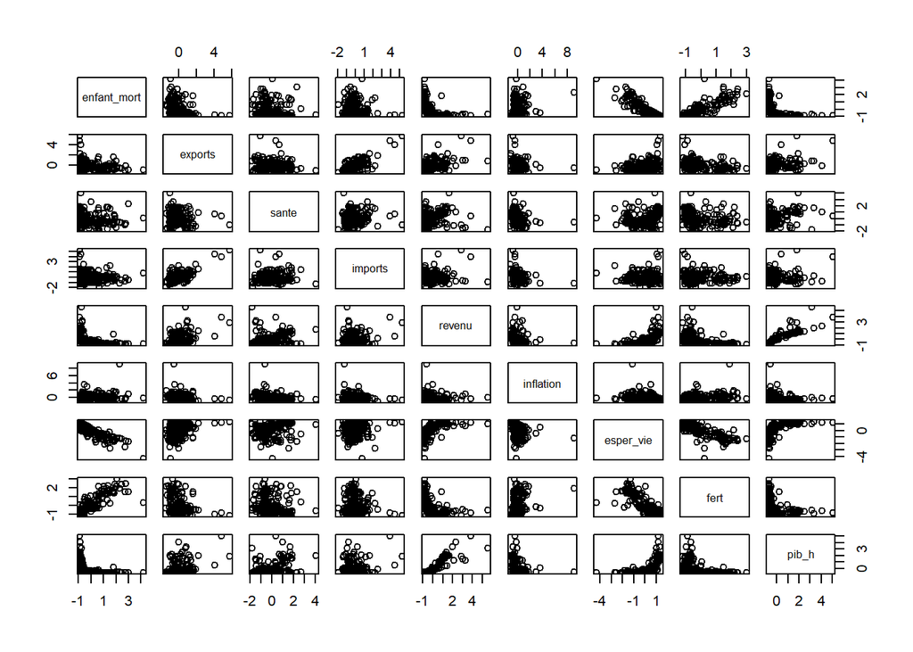

```r
pairs(donnees.sc)
```

On calcule d’abord la distance euclidienne au carré. Le calcul de la distance euclidienne nous permettra par la suite d’être optimal lors de l’utilisation de la stratégie de Ward.

```r
D <- dist(donnees.sc,method="euclidean")^2
```

Méthode CAH avec le saut minimal (single linkage) :

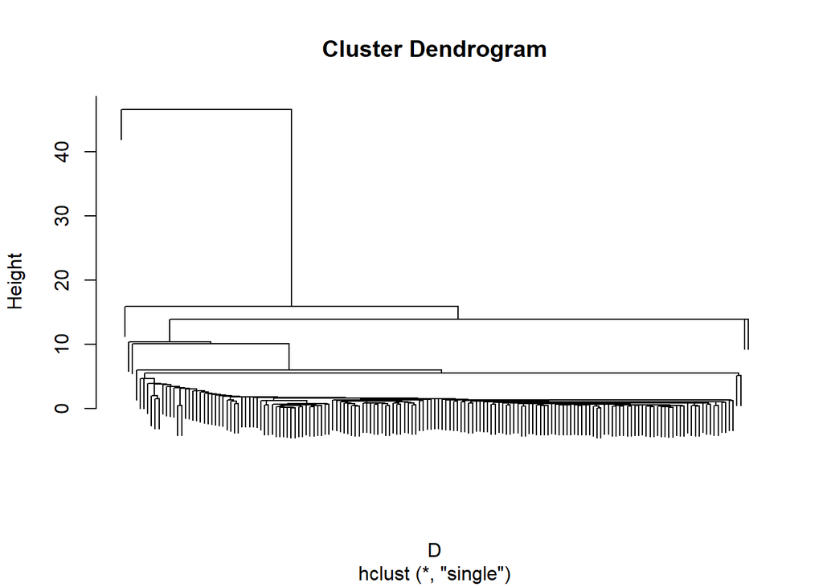

```r
CAH_min <- hclust(d= D,method="single")
plot(CAH_min, labels = FALSE)
```

Ce premier dendrogramme n’est pas très explicite et ne nous permet pas de faire un choix de partition clair.

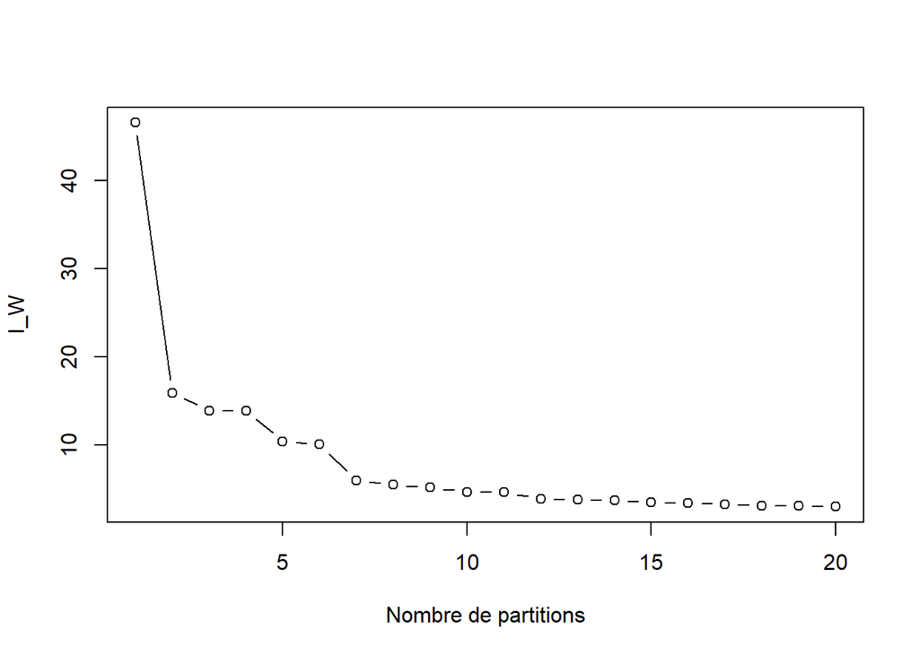

```r
plot(rev(CAH_min$height)[1:20],type="b",xlab="Nombre de partitions",ylab="I_W")
```

Cependant, le tracé de la pertie d’inertie nous suggère de choisir une partition en 2 groupes. Nous avons choisi de représenter seulement les 20 premières valeurs pour ne pas “noyer” l’information importante. Chaque coupure correspond à un saut important d’inertie intra-classes.

Faisons maintant les mêmes graphiques avec la méthode de distance de saut maximal (complet linkage).

Méthode CAH avec le saut maximal :

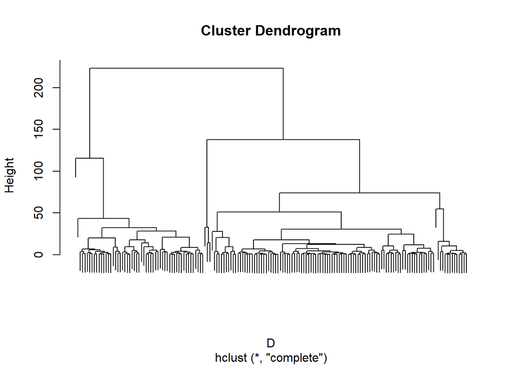

```r
CAH_max <- hclust(d= D,method="complete")
plot(CAH_max, labels = FALSE)
```

En analysant ce dendrogramme, nous pouvons distinguer 3 groupes de pays : un à droite, un au milieu et un à gauche.

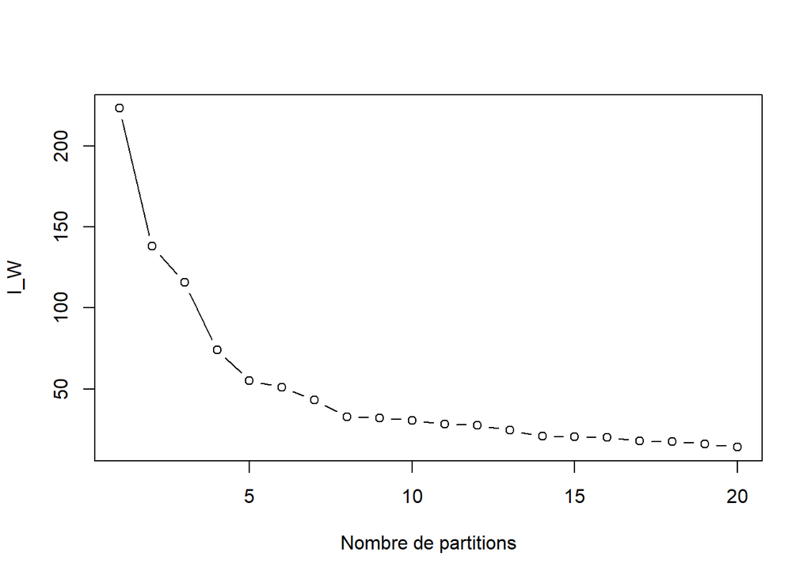

```r
plot(rev(CAH_max$height)[1:20],type="b",xlab="Nombre de partitions",ylab="I_W")
```

Le graphique ci-dessus n’est pas très concluant quant à l’hypothèse de partition en deux groupes. Nous nous posons la question d’une éventuelle partition en cinq groupes de pays en observant les sauts d’inertie intra-classes. En effet, ayant un budget limité, cette approche nous permettrait de diviser au mieux notre budget. Nous continuons donc nos analyses.

CAH avec la distance de Ward :

Enfin, avec la distance de ward, on obtient les résultats suivants :

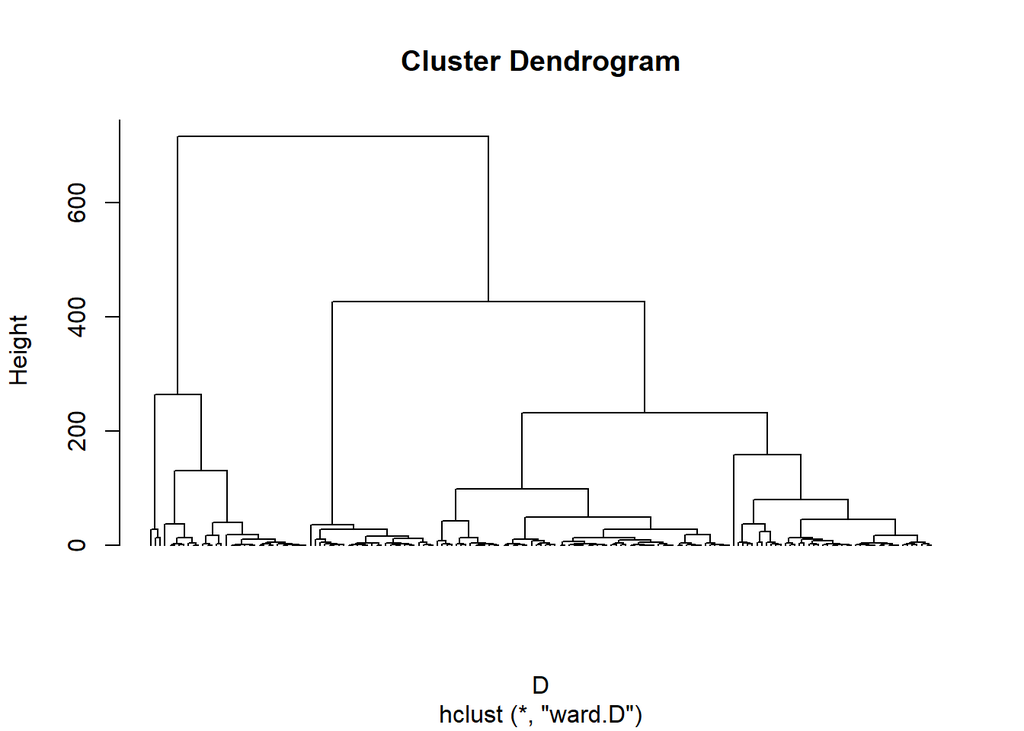

```r
CAH_ward <- hclust( d = D,method="ward.D")
plot(CAH_ward,hang=-1,labels=FALSE)
```

Le dendrogramme nous permet aussi de supposer l’existence de cinq groupes de pays.

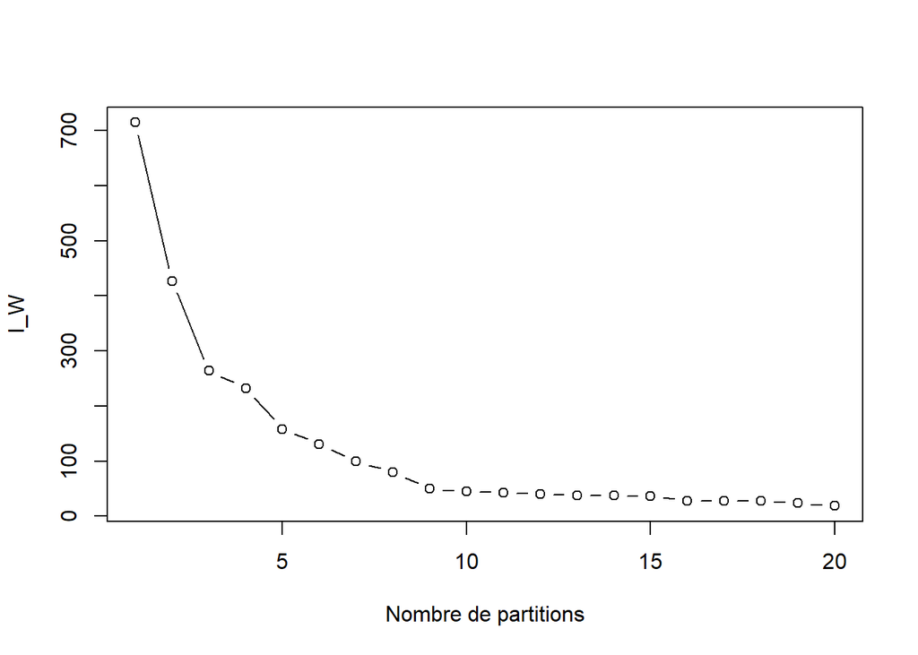

```r
plot(rev(CAH_ward$height)[1:20],type="b",xlab="Nombre de partitions",ylab="I_W")
```

Ce tracé de la perte d’inertie intra-classes nous indique quatre voire cinq groupes.

En conclusion, nous avons décidé de chosisir une partition en cinq groupes afin de diviser au mieux notre budget et de se focaliser sur les pays les plus nécessiteux.

Critère automatique à partir du package ‘NbClust’ :

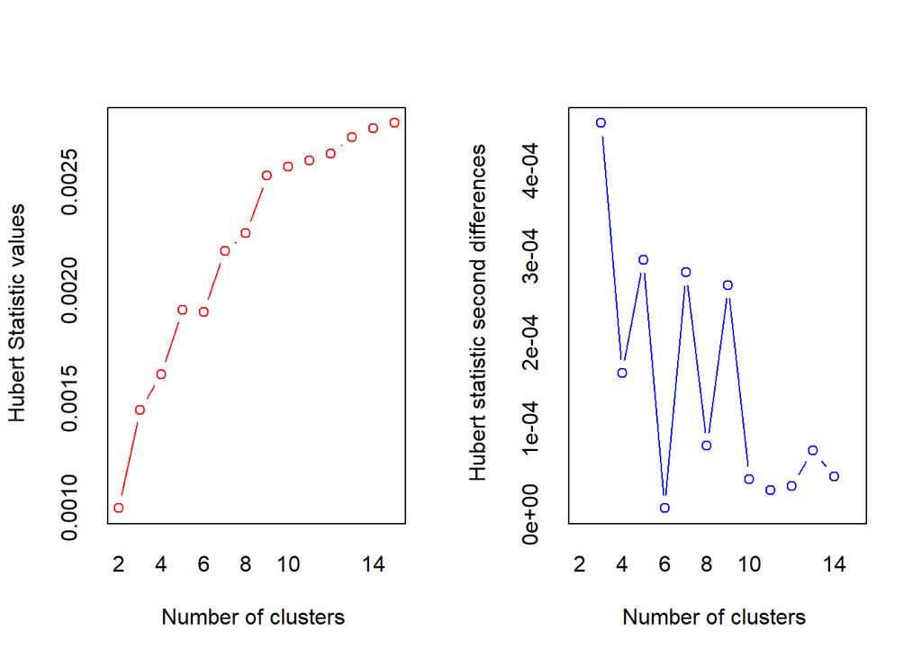

```
## *** : The Hubert index is a graphical method of determining the number of clusters.
##                 In the plot of Hubert index, we seek a significant knee that corresponds to a
##                 significant increase of the value of the measure i.e the significant peak in Hubert
##                 index second differences plot.
##
```

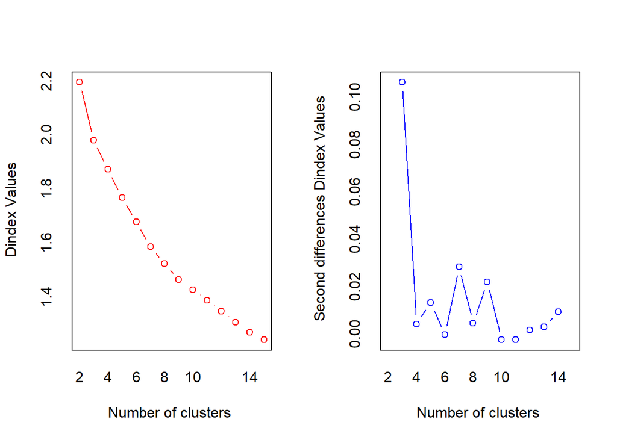

```
## *** : The D index is a graphical method of determining the number of clusters.
##                 In the plot of D index, we seek a significant knee (the significant peak in Dindex
##                 second differences plot) that corresponds to a significant increase of the value of
##                 the measure.
##
## * Among all indices:
## * 5 proposed 2 as the best number of clusters
## * 4 proposed 3 as the best number of clusters
## * 5 proposed 4 as the best number of clusters
## * 1 proposed 5 as the best number of clusters
## * 1 proposed 8 as the best number of clusters
## * 4 proposed 9 as the best number of clusters
## * 1 proposed 12 as the best number of clusters
## * 1 proposed 14 as the best number of clusters
## * 1 proposed 15 as the best number of clusters
##
##                    ***** Conclusion *****
##
## * According to the majority rule, the best number of clusters is  2
##
##
```

[output not shown]

[output cut: 192 more lines]

[output not shown]

```r
NbClust(donnees.sc,min.nc = 2,max.nc = 15,method="ward.D",index="all")
```

Cette étape nous permet de conclure que le choix le plus pertinent serait une partition en 2 groupes. Cependant, notre budget étant limité, nous allons devoir diviser notre échantillon en 5 groupes.

#### Interprétation des groupes :

Représentation graphique des clusters avec un dendrogramme :

Dans notre cas, on fixe K = 5 car nous avons choisi de réaliser une partition en 5 groupes.

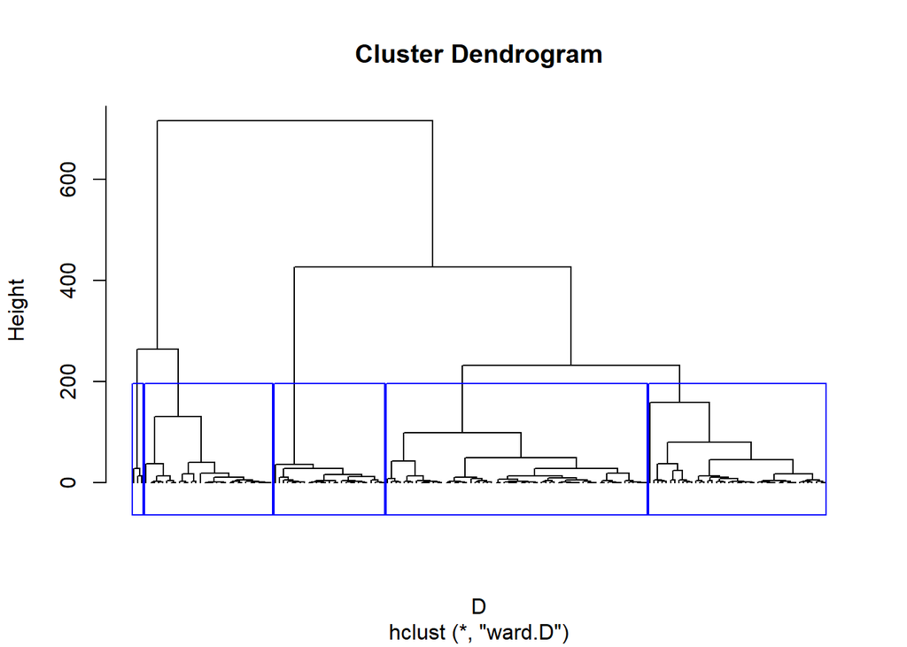

```r
K=5
plot(CAH_ward,hang=-1,labels=FALSE)
rect.hclust(CAH_ward,K,border="blue")
```

Représentation graphique des clusters avec la fonction cutree :

La fonction cutree permet de faire apparaitre visuellement les groupes.

```r
K = 5
gpe.ward <-  cutree(CAH_ward,k=K)
donnees  <- cbind(donnees,gpe.ward)
donnees$gpe.ward <- as.factor(donnees$gpe.ward)
# plot(gpe.ward)
interp_cah <- catdes(donnees,num.var = 10)
# interp_cah
```

```r
nrow(donnees[donnees$gpe.ward==1,])
```

```
## [1] 27
```

Le groupe nécessiteux est composé de 27 pays.

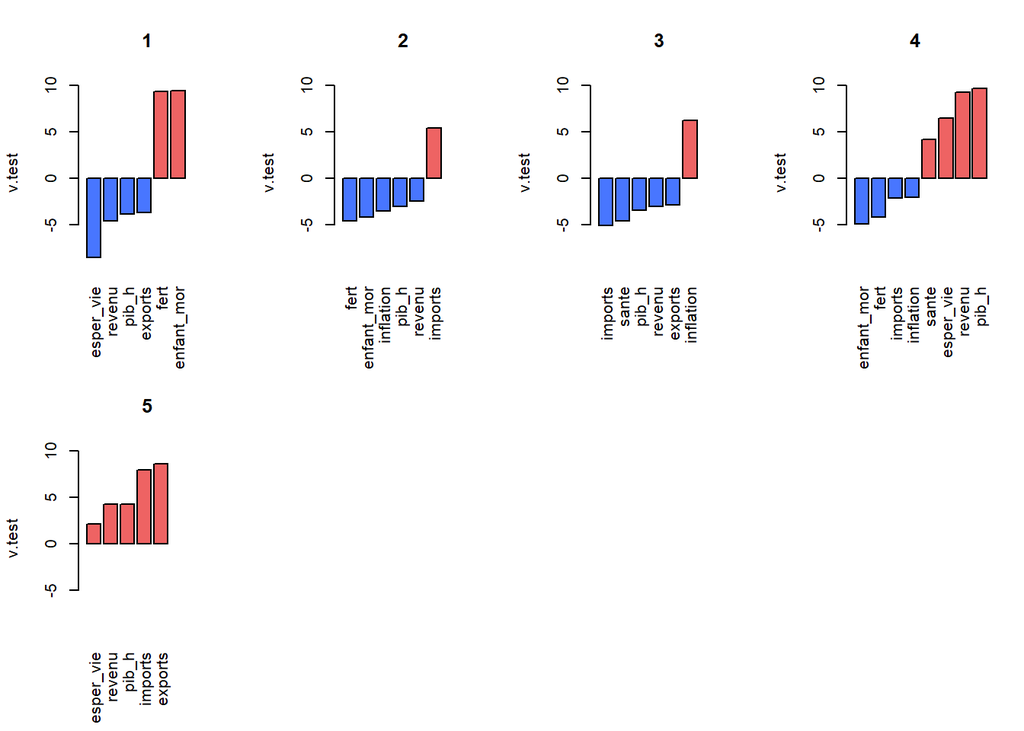

```r
plot.catdes(interp_cah,barplot = T)
```

A l’aide des deux sorties précédentes, nous remarquons que les groupes présentent des caractéristiques opposées. Le premier groupe est caractérisé par un faible taux de PIB par habitant, de revenu et d’espérance de vie. De plus, le taux d’enfants morts est plus important dans ce groupe-ci. Nous pouvons donc supposer que ce groupe comporte des pays plus défavorisés et en difficultés.

Par ailleurs, le second groupe présente des caractéristiques communes comme le PIB par habitant et le revenu. Le taux d’importation étant assez élevé nous pouvons nous demander si ces pays dépendants des économies extérieurs.

Le dernier groupe comporte des pays plus riches avec une production et des exportations importantes.

Représentation sur les deux premiers axes d’une ACP:

```r
CCpca = dudi.pca(donnees.sc,scannf=FALSE,nf=2)
cumsum(CCpca$eig)/sum(CCpca$eig) # ?% de variabilité expliquée sur les deux premiers axes
```

```
## [1] 0.4595174 0.6313337 0.7613762 0.8719079 0.9453100 0.9701523 0.9827566
## [8] 0.9925694 1.0000000
```

```r
scatter(CCpca,posieig = "none",clab.row=0,pch=NA)
```

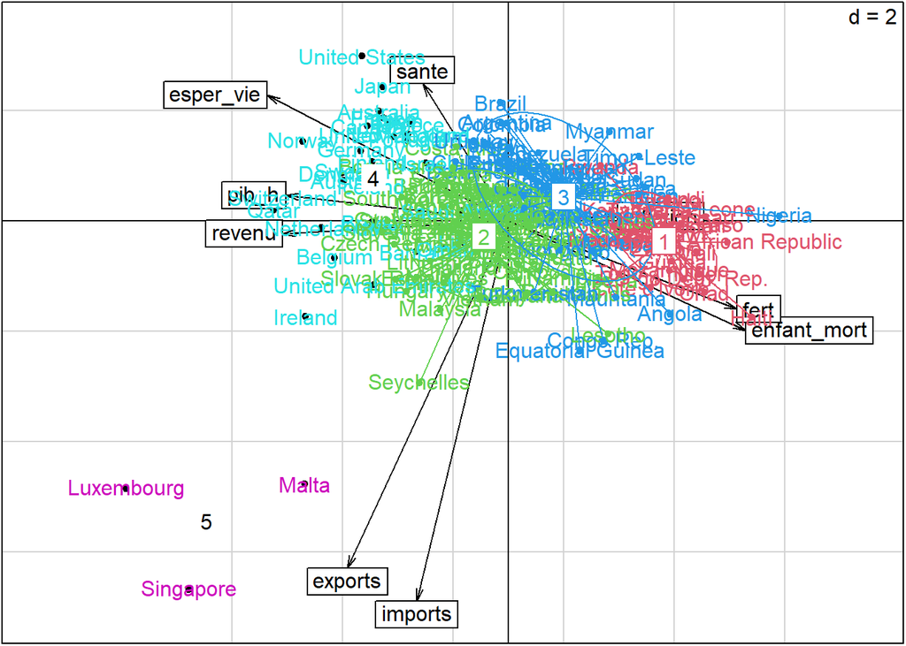

```r
text(CCpca$li[,1], CCpca$li[,2],labels =row.names(donnees),col=gpe.ward+1,xpd=TRUE)
s.class(CCpca$li, factor(gpe.ward), col = 2:4, add.plot = TRUE,clabel = 1)
```

L’ACP nous présente les deux axes déterminants pour nos pays.  
L’axe 1 est caractérisé par un nombre moyen d’enfants par femme important et de décès d’enfants de moins de 5 ans. Ces deux composantes sont synonymes de pauvreté et d’un faible développement du pays. Nous devons donc aider en priorité les pays corrélés positivement avec l’axe 1.  
De plus, lorsque les pays sont corrélés négativement avec l’axe 2, les dépenses de santé sont très faibles.

Représentation des groupes avec la fonction clusplot :

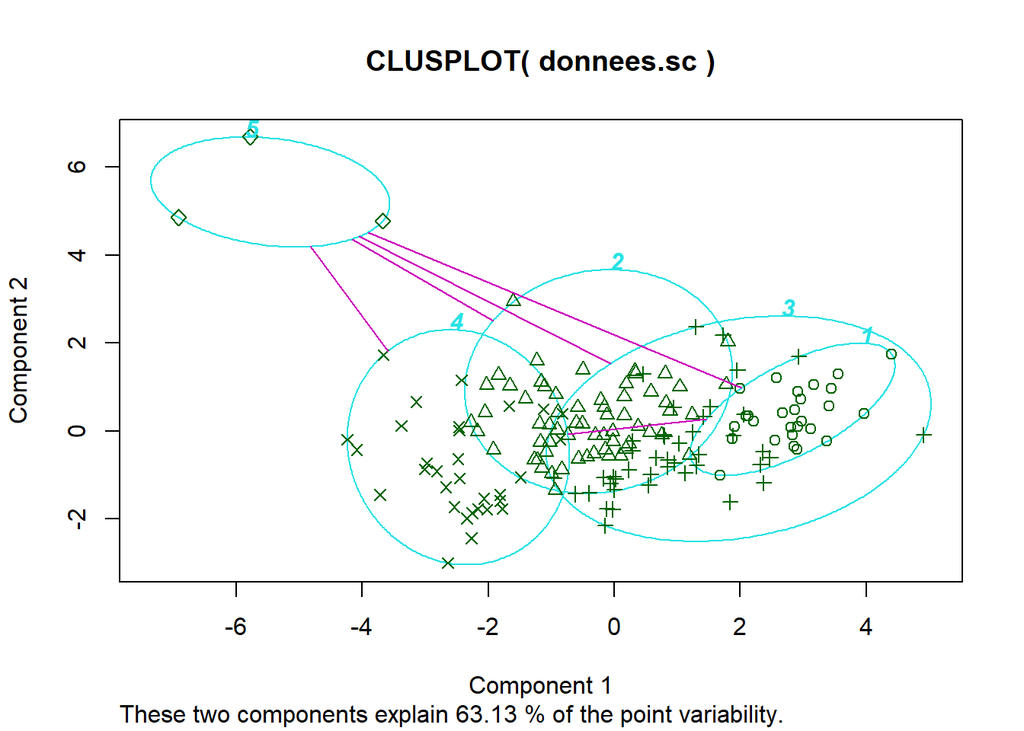

```r
K = 5
clusplot(donnees.sc,cutree(CAH_ward,K),labels=4)
```

Ce graphe correspond à la représentation des groupes sur les deux premiers axes principaux d’une ACP. De plus, des ellipses de contour autour des groupes sont tracées. Ici, nous pouvons voir 5 groupes.